# Case Stydy 1

Fabio

6/23/2019

```r
knitr::opts_chunk$set(echo = TRUE)
```

# Dependencies

### This are the libraries that we will use in this projec

```r
library(dplyr)
library(ggplot2)
library(tidyr)
library(reshape2)
library(tidyverse)
```

### We are loading the dataset from the beers and the dataset from breweries in the chunk code below.The beers dataset is bears, the breweries dataset is brew.

```r
url<-"https://raw.githubusercontent.com/BivinSadler/MSDS-6306-Doing-Data-Science/master/Unit%207/Beers.csv"
beers <- read.csv(url(url), sep = ",", header = TRUE)
head(beers)
```

```
##                  Name Beer_ID   ABV IBU Brewery_id
## 1            Pub Beer    1436 0.050  NA        409
## 2         Devil's Cup    2265 0.066  NA        178
## 3 Rise of the Phoenix    2264 0.071  NA        178
## 4            Sinister    2263 0.090  NA        178
## 5       Sex and Candy    2262 0.075  NA        178
## 6        Black Exodus    2261 0.077  NA        178
##                            Style Ounces
## 1            American Pale Lager     12
## 2        American Pale Ale (APA)     12
## 3                   American IPA     12
## 4 American Double / Imperial IPA     12
## 5                   American IPA     12
## 6                  Oatmeal Stout     12
```

```r
url<-"https://raw.githubusercontent.com/BivinSadler/MSDS-6306-Doing-Data-Science/master/Unit%207/Breweries.csv"
brew <- read.csv(url(url), sep = ",", header = TRUE)
head(brew)
```

```
##   Brew_ID                      Name          City State
## 1       1        NorthGate Brewing    Minneapolis    MN
## 2       2 Against the Grain Brewery    Louisville    KY
## 3       3  Jack's Abby Craft Lagers    Framingham    MA
## 4       4 Mike Hess Brewing Company     San Diego    CA
## 5       5   Fort Point Beer Company San Francisco    CA
## 6       6     COAST Brewing Company    Charleston    SC
```

# QUESTION 1: BREWERIES PER STATE

### In the following code we count how many breweries are pers state in the US territory. NumBreweries describe the amount of breweries per state in the US territory.Then we ordered in descending order the NumBreweries. Colorado and California are the states with the highest amount of breweries in their state. The states with only one brewere are DC,ND,SD WD.

```r
# changing from factor to char
brew$State <- as.character(brew$State)
# changing to int
brew$Brew_ID <- as.integer(brew$Brew_ID)
# changing to char
brew$Name <-  as.character(brew$Name)
# removing trailing whitespace
str_trim(brew$State, side = "left") -> brew$State
brew %>% group_by(State) %>% summarize(numBreweries = n_distinct(Name)) -> numBreweries
numBreweries <- arrange(numBreweries, desc(numBreweries))
head(numBreweries)
```

```
## # A tibble: 6 x 2
##   State numBreweries
##   <chr>        <int>
## 1 CO              46
## 2 CA              39
## 3 MI              32
## 4 OR              29
## 5 TX              28
## 6 PA              24
```

```r
tail(numBreweries)
```

```
## # A tibble: 6 x 2
##   State numBreweries
##   <chr>        <int>
## 1 MS               2
## 2 NV               2
## 3 DC               1
## 4 ND               1
## 5 SD               1
## 6 WV               1
```

### Creating chart for breweries in the US territory by States.

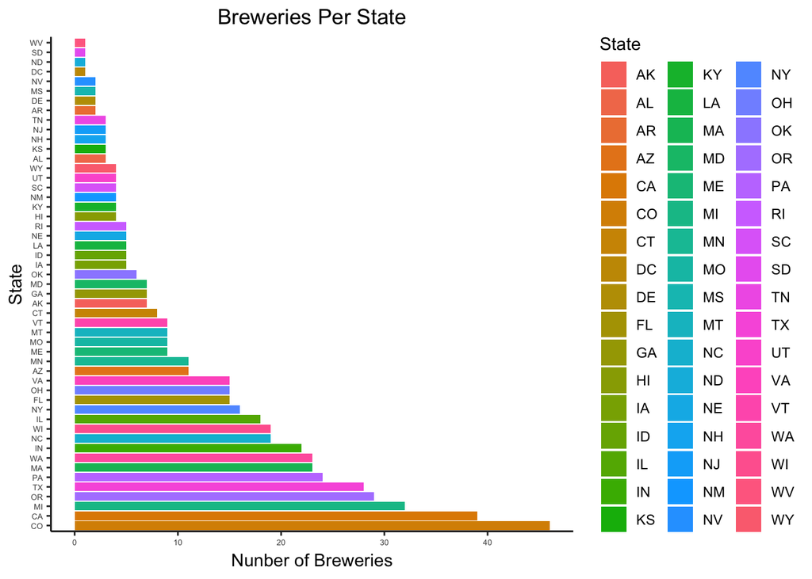

```r
g1= numBreweries %>% ggplot(aes(x = reorder(State,-numBreweries),  y = numBreweries, fill = State))
g2= g1+ geom_col()
g3= g2+coord_flip()
g4= g3+theme(legend.position='none')
g5= g4+theme_classic()+labs(x="State", y="Nunber of Breweries", legend="Nunber of Breweries")+ ggtitle("Breweries Per State")
g6= g5+theme(plot.title = element_text(hjust = 0.5),axis.text=element_text(size=5))
g6
```

# QUESTION 2: MERGED DATA SET

### In the following code chunk we merge beers data with the breweries data. We print the first 6 observations and the last six observations to check the merged file in order to explore the combined dataset. Combined is the combined dataset.

```r
beers$Brew_ID<-beers$Brewery_id
beers$Brewery_id<-NULL
head(beers)
```

```
##                  Name Beer_ID   ABV IBU                          Style
## 1            Pub Beer    1436 0.050  NA            American Pale Lager
## 2         Devil's Cup    2265 0.066  NA        American Pale Ale (APA)
## 3 Rise of the Phoenix    2264 0.071  NA                   American IPA
## 4            Sinister    2263 0.090  NA American Double / Imperial IPA
## 5       Sex and Candy    2262 0.075  NA                   American IPA
## 6        Black Exodus    2261 0.077  NA                  Oatmeal Stout
##   Ounces Brew_ID
## 1     12     409
## 2     12     178
## 3     12     178
## 4     12     178
## 5     12     178
## 6     12     178
```

```r
head(brew)
```

```
##   Brew_ID                      Name          City State
## 1       1        NorthGate Brewing    Minneapolis    MN
## 2       2 Against the Grain Brewery    Louisville    KY
## 3       3  Jack's Abby Craft Lagers    Framingham    MA
## 4       4 Mike Hess Brewing Company     San Diego    CA
## 5       5   Fort Point Beer Company San Francisco    CA
## 6       6     COAST Brewing Company    Charleston    SC
```

```r
combined<- merge(brew, beers,by = "Brew_ID")
# renaming Name.x to Brewery_Name
colnames(combined)[2] <- "Brewery_Name"
# renaming Name.y to Beer_Name
colnames(combined)[5] <- "Beer_Name"
head(combined, 6)
```

```
##   Brew_ID       Brewery_Name        City State     Beer_Name Beer_ID   ABV
## 1       1 NorthGate Brewing  Minneapolis    MN       Pumpion    2689 0.060
## 2       1 NorthGate Brewing  Minneapolis    MN    Stronghold    2688 0.060
## 3       1 NorthGate Brewing  Minneapolis    MN   Parapet ESB    2687 0.056
## 4       1 NorthGate Brewing  Minneapolis    MN  Get Together    2692 0.045
## 5       1 NorthGate Brewing  Minneapolis    MN Maggie's Leap    2691 0.049
## 6       1 NorthGate Brewing  Minneapolis    MN    Wall's End    2690 0.048
##   IBU                               Style Ounces
## 1  38                         Pumpkin Ale     16
## 2  25                     American Porter     16
## 3  47 Extra Special / Strong Bitter (ESB)     16
## 4  50                        American IPA     16
## 5  26                  Milk / Sweet Stout     16
## 6  19                   English Brown Ale     16
```

```r
tail(combined, 6)
```

```
##      Brew_ID                  Brewery_Name          City State
## 2405     556         Ukiah Brewing Company         Ukiah    CA
## 2406     557       Butternuts Beer and Ale Garrattsville    NY
## 2407     557       Butternuts Beer and Ale Garrattsville    NY
## 2408     557       Butternuts Beer and Ale Garrattsville    NY
## 2409     557       Butternuts Beer and Ale Garrattsville    NY
## 2410     558 Sleeping Lady Brewing Company     Anchorage    AK
##                      Beer_Name Beer_ID   ABV IBU                   Style
## 2405             Pilsner Ukiah      98 0.055  NA         German Pilsener
## 2406         Porkslap Pale Ale      49 0.043  NA American Pale Ale (APA)
## 2407           Snapperhead IPA      51 0.068  NA            American IPA
## 2408         Moo Thunder Stout      50 0.049  NA      Milk / Sweet Stout
## 2409  Heinnieweisse Weissebier      52 0.049  NA              Hefeweizen
## 2410 Urban Wilderness Pale Ale      30 0.049  NA        English Pale Ale
##      Ounces
## 2405     12
## 2406     12
## 2407     12
## 2408     12
## 2409     12
## 2410     12
```

# QUESTION 3: MISSING DATA

### In the following chunk code we report the number of NA’s in each column of the combined dataset. NA_count is the amountof NA in each column in the combined dataset.

```r
na_count <-sapply(combined, function(y) sum(length(which(is.na(y)))))
na_count
```

```
##      Brew_ID Brewery_Name         City        State    Beer_Name
##            0            0            0            0            0
##      Beer_ID          ABV          IBU        Style       Ounces
##            0           62         1005            0            0
```

# QUESTION 4: MEDIAN ALCOHOL CONTENT

### We compute the median alcohol content and international bitterness unit in a beer for each state from the combined dataset. In order to compute the alcohol content and international bitterness unit in a beer for each state from the combined dataset, we grouped the combined dataset by State, then we sumarized by alcohol content and international bitterness unit per beer using the median function. We decided to get rid of the NA values, we used the pipe function from the dplyr library to design this code. The final product of the function is plot1.

```r
combined %>% group_by(State) %>% summarize(Alcohol_content = median(ABV, na.rm = TRUE), Bitterness= median(IBU, na.rm = TRUE)) ->plot1
plot1
```

```
## # A tibble: 51 x 3
##    State Alcohol_content Bitterness
##    <chr>           <dbl>      <dbl>
##  1 AK             0.056        46
##  2 AL             0.06         43
##  3 AR             0.052        39
##  4 AZ             0.055        20.5
##  5 CA             0.058        42
##  6 CO             0.0605       40
##  7 CT             0.06         29
##  8 DC             0.0625       47.5
##  9 DE             0.055        52
## 10 FL             0.057        55
## # … with 41 more rows
```

### We Plot a bar chart to compare the median alcohol content and international bitterness unit per beer for each state from the combined dataset. We used the ggplot library to perform the plot.

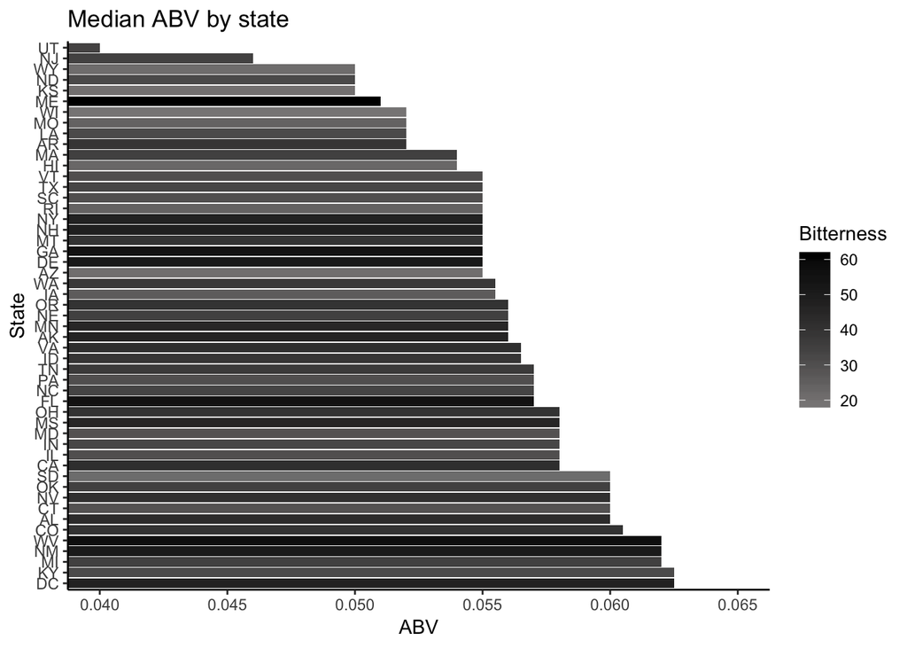

```r
g1= ggplot(plot1, aes(x=reorder(State,-Alcohol_content),y=Alcohol_content, fill=Bitterness))
g2=  g1 + geom_bar(stat="identity")
g3= g2+coord_flip(ylim=c(.04,.0650))
g4= g3+theme(legend.position='none')
g5= g4+ scale_fill_gradient2(midpoint=median(plot1$Alcohol_content),low='red', mid='snow3', high='black', space='Lab')
g6= g5+theme_classic()+labs(x="State", y="ABV", legend="ABV")+ ggtitle("Median ABV by state")
g6
```

### In the following chunk code we performend the following caculation. The top 5 state with more alcohol content, which is HAC_S. The top 5 state with the most bitter beer, which is HB_S. Furtheremore, we proceed to plot HAC_S and HB_S. Previously we clean the data in order no to have repeated the same state with the function distint.

```r
df_unique <-distinct(combined[order(combined$ABV, decreasing = T, na.last = T),], State, .keep_all = TRUE)
HAC_S <-head(df_unique,5)
HAC_S
```

```
##   Brew_ID              Brewery_Name         City State
## 1      52   Upslope Brewing Company      Boulder    CO
## 2       2 Against the Grain Brewery   Louisville    KY
## 3      18   Tin Man Brewing Company   Evansville    IN
## 4      47       Sixpoint Craft Ales     Brooklyn    NY
## 5      11            Brewery Vivant Grand Rapids    MI
##                                              Beer_Name Beer_ID   ABV IBU
## 1 Lee Hill Series Vol. 5 - Belgian Style Quadrupel Ale    2565 0.128  NA
## 2                                       London Balling    2685 0.125  80
## 3                                                 Csar    2621 0.120  90
## 4                                               4Beans    2574 0.100  52
## 5                                 Wizard Burial Ground    2137 0.099  NA
##                    Style Ounces
## 1       Quadrupel (Quad)   19.2
## 2     English Barleywine   16.0
## 3 Russian Imperial Stout   16.0
## 4          Baltic Porter   12.0
## 5       Quadrupel (Quad)   16.0
```

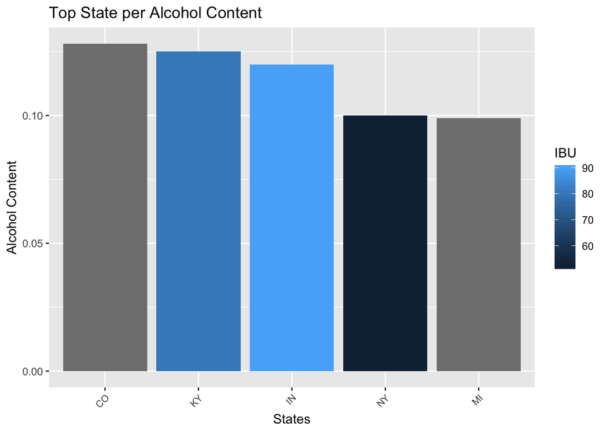

```r
ggplot(data=HAC_S, aes(x= reorder(State,-ABV), y=ABV, fill= IBU)) + geom_bar(stat="identity") + ggtitle("Top State per Alcohol Content") + labs(x= "States",  y= "Alcohol Content") + theme(axis.text.x = element_text(size =8, angle =45, hjust = 1, vjust = 1))
```

```r
HB_S<-head(combined[order(combined$IBU, decreasing = T, na.last = T),],5)
HB_S
```

```
##      Brew_ID                       Brewery_Name            City State
## 1857     375            Astoria Brewing Company         Astoria    OR
## 1719     345         Wolf Hills Brewing Company        Abingdon    VA
## 1305     231           Cape Ann Brewing Company      Gloucester    MA
## 625      100 Christian Moerlein Brewing Company      Cincinnati    OH
## 425       62              Surly Brewing Company Brooklyn Center    MN
##                            Beer_Name Beer_ID   ABV IBU
## 1857       Bitter Bitch Imperial IPA     980 0.082 138
## 1719              Troopers Alley IPA    1676 0.059 135
## 1305                   Dead-Eye DIPA    2067 0.090 130
## 625  Bay of Bengal Double IPA (2014)    2440 0.089 126
## 425                     Abrasive Ale      15 0.097 120
##                               Style Ounces
## 1857 American Double / Imperial IPA     12
## 1719                   American IPA     12
## 1305 American Double / Imperial IPA     16
## 625  American Double / Imperial IPA     12
## 425  American Double / Imperial IPA     16
```

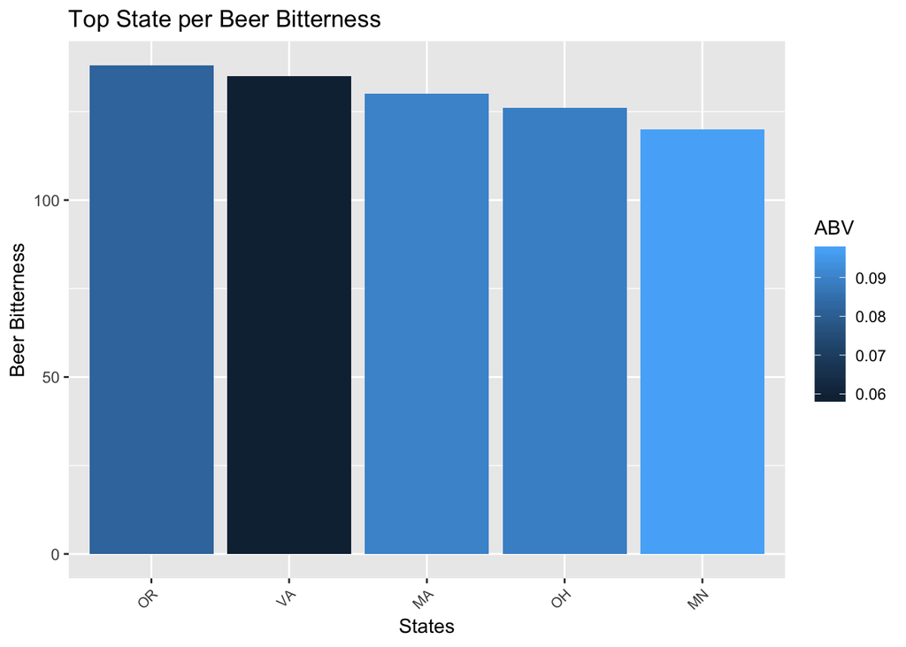

```r
ggplot(data=HB_S, aes(x= reorder(State,-IBU), y=IBU, fill= ABV)) + geom_bar(stat="identity") + ggtitle("Top State per Beer Bitterness") + labs(x= "States",  y= "Beer Bitterness") + theme(axis.text.x = element_text(size =8, angle =45, hjust = 1, vjust = 1))
```

```r
LAC_S<-tail(combined[order(combined$ABV, decreasing = T, na.last = F),],5)
LAC_S
```

```
##      Brew_ID                     Brewery_Name            City State
## 2341     529        Asheville Brewing Company       Asheville    NC
## 670      110 Woodstock Inn, Station & Brewery North Woodstock    NH
## 528       81           Hopworks Urban Brewery        Portland    OR
## 1058     174                Evil Twin Brewing        Brooklyn    NY
## 2327     523                 Uncommon Brewers      Santa Cruz    CA
##           Beer_Name Beer_ID   ABV IBU            Style Ounces
## 2341    Rocket Girl     550 0.032  27           Kölsch     12
## 670     Summer Brew    2306 0.028  15 American Pilsner     12
## 528  Totally Radler    2482 0.027  21           Radler     16
## 1058    Bikini Beer    1286 0.027  NA     American IPA     12
## 2327    Scotty K NA     606 0.001  NA Low Alcohol Beer     16
```

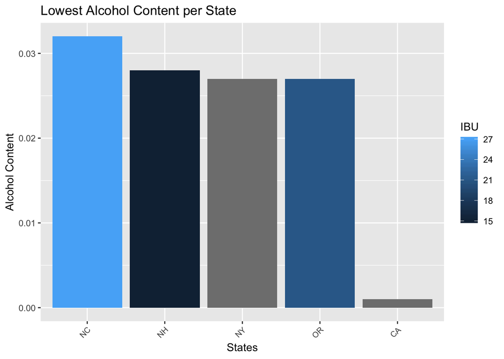

```r
ggplot(data=LAC_S, aes(x= reorder(State,-ABV), y=ABV, fill= IBU)) + geom_bar(stat="identity") + ggtitle("Lowest Alcohol Content per State") + labs(x= "States",  y= "Alcohol Content") + theme(axis.text.x = element_text(size =8, angle =45, hjust = 1, vjust = 1))
```

```r
df_unique <-distinct(combined[order(combined$IBU, decreasing = T, na.last = F),], State, .keep_all = TRUE)
LB_S <-tail(na.omit(df_unique),5)
LB_S
```

```
##    Brew_ID                        Brewery_Name               City State
## 48     223              Carton Brewing Company Atlantic Highlands    NJ
## 49     134 Southern Prohibition Brewing Com...        Hattiesburg    MS
## 50     157   Greenbrier Valley Brewing Company          Lewisburg    WV
## 51     336               Fargo Brewing Company              Fargo    ND
##                      Beer_Name Beer_ID   ABV IBU                    Style
## 48                     Epitome    2094 0.099 100       American Black Ale
## 49        Mississippi Fire Ant    1745 0.080  80 American Amber / Red Ale
## 50           Mothman Black IPA    2313 0.067  71       American Black Ale
## 51 Wood Chipper India Pale Ale    1434 0.067  70             American IPA
##    Ounces
## 48     16
## 49     16
## 50     12
## 51     12
```

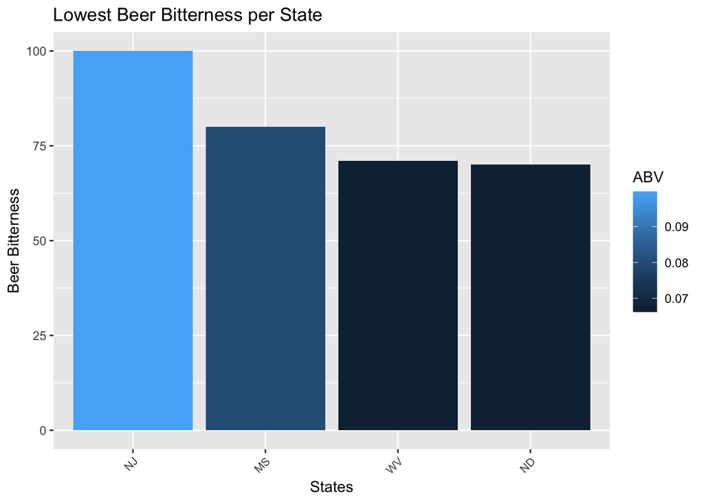

```r
ggplot(data=LB_S, aes(x= reorder(State,-IBU), y=IBU, fill= ABV)) + geom_bar(stat="identity") + ggtitle("Lowest Beer Bitterness per State") + labs(x= "States",  y= "Beer Bitterness") + theme(axis.text.x = element_text(size =8, angle =45, hjust = 1, vjust = 1))
```

# QUESTION 5: MAX IBU & ABV STATES

### The following code show the state with the maximum alcoholic (ABV) beer, and the state with the most bitter (IBU) beer. The maximum alcoholic (ABV) beer, and bitter (IBU) beer is represened in the code below

```r
# Highest Alcohol Content is HAC, the highest alcohol content in its state is HAC_S
HAC<- head(beers[order(beers$ABV, decreasing = T, na.last = T),],1)
HAC
```

```
##                                                      Name Beer_ID   ABV
## 2279 Lee Hill Series Vol. 5 - Belgian Style Quadrupel Ale    2565 0.128
##      IBU            Style Ounces Brew_ID
## 2279  NA Quadrupel (Quad)   19.2      52
```

```r
HAC_S<-head(combined[order(combined$ABV, decreasing = T, na.last = T),],1)
HAC_S
```

```
##     Brew_ID            Brewery_Name    City State
## 384      52 Upslope Brewing Company Boulder    CO
##                                                Beer_Name Beer_ID   ABV IBU
## 384 Lee Hill Series Vol. 5 - Belgian Style Quadrupel Ale    2565 0.128  NA
##                Style Ounces
## 384 Quadrupel (Quad)   19.2
```

```r
# Highest Bitterness is HB, the highest bitterness in its state is HB_S
HB<-head(beers[order(beers$IBU, decreasing = T, na.last = T),],1)
HB
```

```
##                          Name Beer_ID   ABV IBU
## 148 Bitter Bitch Imperial IPA     980 0.082 138
##                              Style Ounces Brew_ID
## 148 American Double / Imperial IPA     12     375
```

```r
HB_S<-head(combined[order(combined$IBU, decreasing = T, na.last = T),],1)
HB_S
```

```
##      Brew_ID            Brewery_Name    City State
## 1857     375 Astoria Brewing Company Astoria    OR
##                      Beer_Name Beer_ID   ABV IBU
## 1857 Bitter Bitch Imperial IPA     980 0.082 138
##                               Style Ounces
## 1857 American Double / Imperial IPA     12
```

# QUESTION 6: SUMMARY STATS FOR ABV

```r
summary(beers$ABV)
```

```
##    Min. 1st Qu.  Median    Mean 3rd Qu.    Max.    NA's
## 0.00100 0.05000 0.05600 0.05977 0.06700 0.12800      62
```

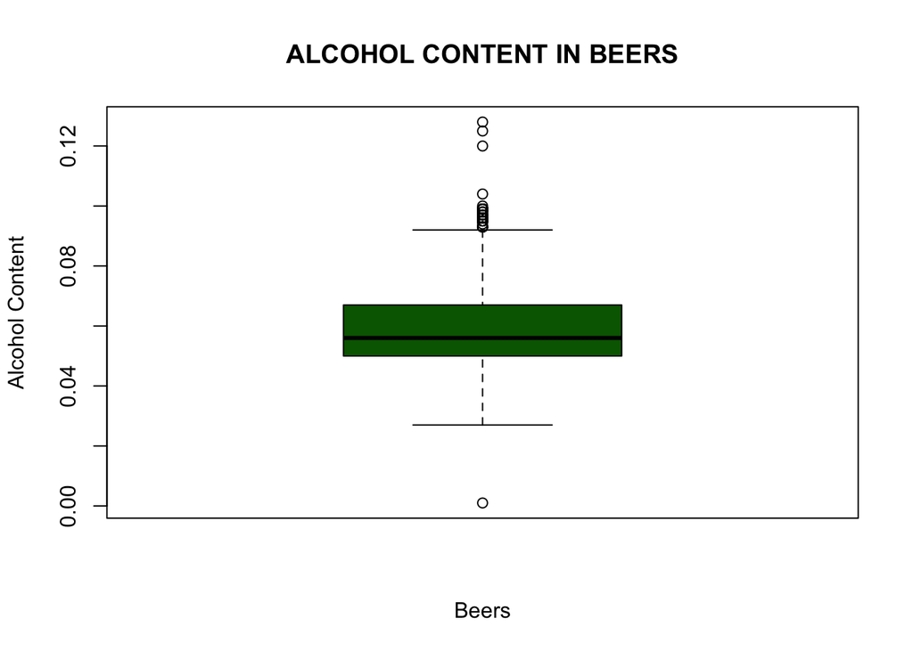

```r
boxplot(beers$ABV, main=toupper("Alcohol Content in Beers"), font.main=3, cex.main=1.2, xlab="Beers", ylab="Alcohol Content", font.lab=3, col="darkgreen")
```

### Summary statistics for the IBU variable from the beers dataset. Median 35, mean 42.71.

```r
summary(beers$IBU)
```

```
##    Min. 1st Qu.  Median    Mean 3rd Qu.    Max.    NA's
##    4.00   21.00   35.00   42.71   64.00  138.00    1005
```

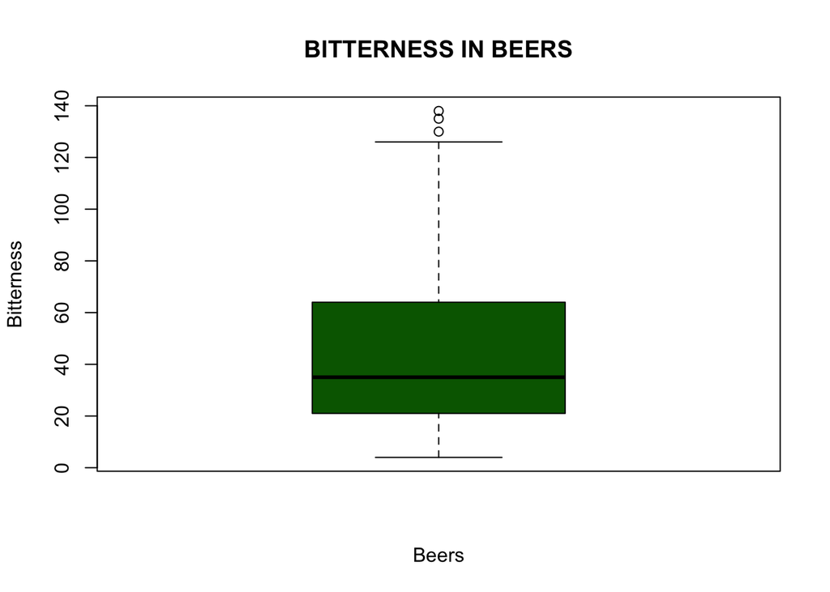

```r
boxplot(beers$IBU, main=toupper("Bitterness in Beers"), font.main=3, cex.main=1.2, xlab="Beers", ylab="Bitterness", font.lab=3, col="darkgreen")
```

# QUESTION 7: ABV & IBU RELATIONSHIP

### Scatterplot between Alcohol & Bitterness. It look like bitterness of 42 and alcohol content of 0.06 would be a good combination in a particular beer type of production.

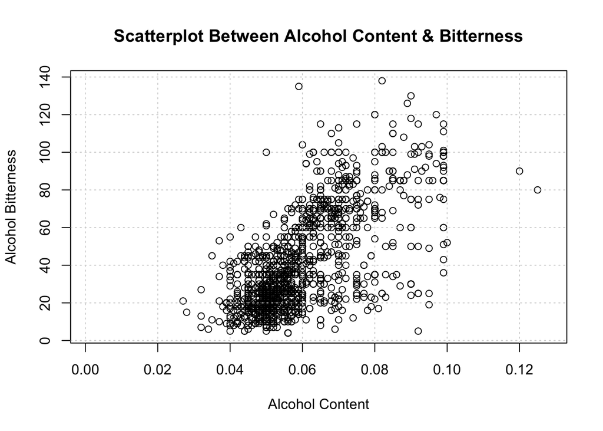

```r
grid(plot(combined$ABV, combined$IBU, main="Scatterplot Between Alcohol Content & Bitterness", xlab = "Alcohol Content", ylab = "Alcohol Bitterness"))
```

```r
cor.test(combined$ABV, combined$IBU, na.action(na.omit("NA")))
```

```
##
##  Pearson's product-moment correlation
##
## data:  combined$ABV and combined$IBU
## t = 33.863, df = 1403, p-value < 2.2e-16
## alternative hypothesis: true correlation is not equal to 0
## 95 percent confidence interval:
##  0.6407982 0.6984238
## sample estimates:
##       cor
## 0.6706215
```

### Predicting bitterness based on alcohol content.The adjusted R-squared:0.4493. There is poor correlation in this case between the bitterness and alcohol content.

```r
beer.lm <- lm(combined$IBU ~ combined$ABV, na.action(na.omit("NA")))
summary(beer.lm)
```

```
##
## Call:
## lm(formula = combined$IBU ~ combined$ABV, data = na.action(na.omit("NA")))
##
## Residuals:
##     Min      1Q  Median      3Q     Max
## -78.849 -11.977  -0.721  13.997  93.458
##
## Coefficients:
##              Estimate Std. Error t value Pr(>|t|)
## (Intercept)   -34.099      2.326  -14.66   <2e-16 ***
## combined$ABV 1282.037     37.860   33.86   <2e-16 ***
## ---
## Signif. codes:  0 '***' 0.001 '**' 0.01 '*' 0.05 '.' 0.1 ' ' 1
##
## Residual standard error: 19.26 on 1403 degrees of freedom
##   (1005 observations deleted due to missingness)
## Multiple R-squared:  0.4497, Adjusted R-squared:  0.4493
## F-statistic:  1147 on 1 and 1403 DF,  p-value: < 2.2e-16
```

### In the following code using ggplot we draw a scatter plot between the bitterness and alcohol content. It look like there is a trend toward a linear relatioship between the 2 mentioned variable, but it is poor.

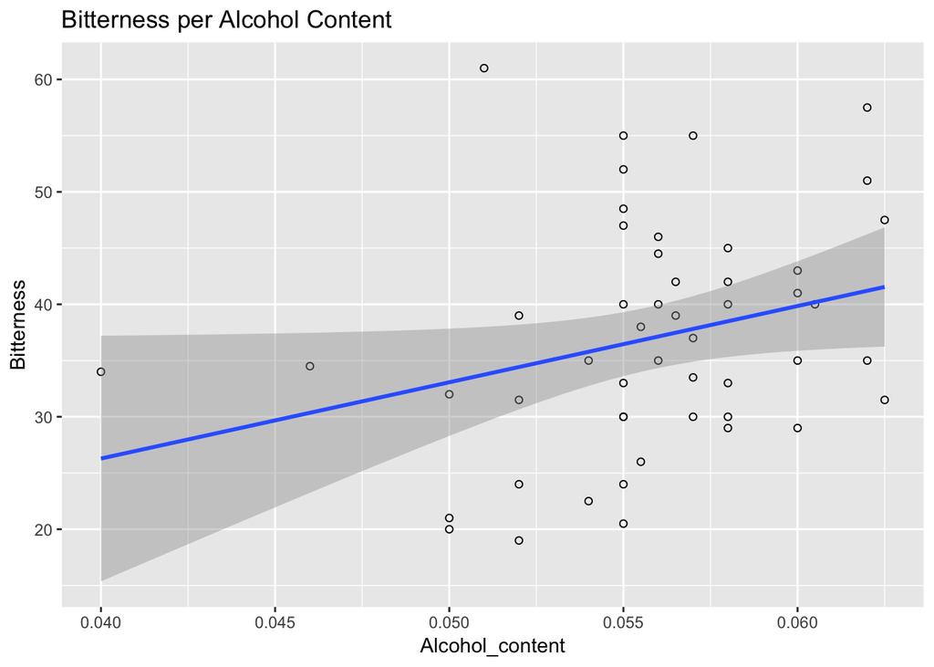

```r
ggplot(dat= plot1, aes(x= Alcohol_content, y= Bitterness)) + geom_point(shape=1) + geom_smooth(method = "lm") + ggtitle("Bitterness per Alcohol Content")
```

### In the following code we found the most frequent beers style and name in the US territory. BeersStyle is the most frequent beer style. BeersName is the most frequent beers name in the US territory.

```r
beers %>% count(Style) %>% arrange(desc(n)) -> BeersStyle
BeersStyle
```

```
## # A tibble: 100 x 2
##    Style                              n
##    <fct>                          <int>
##  1 American IPA                     424
##  2 American Pale Ale (APA)          245
##  3 American Amber / Red Ale         133
##  4 American Blonde Ale              108
##  5 American Double / Imperial IPA   105
##  6 American Pale Wheat Ale           97
##  7 American Brown Ale                70
##  8 American Porter                   68
##  9 Saison / Farmhouse Ale            52
## 10 Witbier                           51
## # … with 90 more rows
```

```r
beers %>% count(Name) %>% arrange(desc(n)) -> BeersName
BeersName
```

```
## # A tibble: 2,305 x 2
##    Name                       n
##    <fct>                  <int>
##  1 Nonstop Hef Hop           12
##  2 Dale's Pale Ale            6
##  3 Oktoberfest                6
##  4 Longboard Island Lager     4
##  5 1327 Pod's ESB             3
##  6 Boston Lager               3
##  7 Dagger Falls IPA           3
##  8 #9                         2
##  9 312 Urban Pale Ale         2
## 10 312 Urban Wheat Ale        2
## # … with 2,295 more rows
```

# ADDITIONAL QUESTION USING CENSUS DATA

### 2018 Census Data on https://www.census.gov

```r
read.csv(file = "data/population.csv", header = T) -> state_population
state_population$State <- as.character(state_population$State)
```

### Merging census data into brewery by state data, the merged data is combined_pop. We merged this data in order to have the population per state and perform the calculation below. We compared the number of breweries with the state population. This cal culation was performed in order to find if there is a relation between population and breweries.

```r
merge(numBreweries, state_population, by = "State") -> combined_pop
```

### Tests R correlation between Breweries & Total Population By State. Corr 0.6210315, poor correlation.

```r
cor(combined_pop$Population, combined_pop$numBreweries)
```

```
## [1] 0.6210315
```

### Predicting number of breweries based on population. The population number poorly predict the number of breweries Adjusted R-squared: 0.3731

```r
brew_pop.lm <- lm(combined_pop$numBreweries ~ combined_pop$Population)
summary(brew_pop.lm)
```

```
##
## Call:
## lm(formula = combined_pop$numBreweries ~ combined_pop$Population)
##
## Residuals:
##     Min      1Q  Median      3Q     Max
## -10.036  -4.859  -2.391   1.937  35.815
##
## Coefficients:
##                          Estimate Std. Error t value Pr(>|t|)
## (Intercept)             5.131e+00  1.551e+00   3.307  0.00177 **
## combined_pop$Population 8.874e-07  1.600e-07   5.546 1.16e-06 ***
## ---
## Signif. codes:  0 '***' 0.001 '**' 0.01 '*' 0.05 '.' 0.1 ' ' 1
##
## Residual standard error: 8.308 on 49 degrees of freedom
## Multiple R-squared:  0.3857, Adjusted R-squared:  0.3731
## F-statistic: 30.76 on 1 and 49 DF,  p-value: 1.16e-06
```

### Scatterplot Between Breweries & Total Population By State

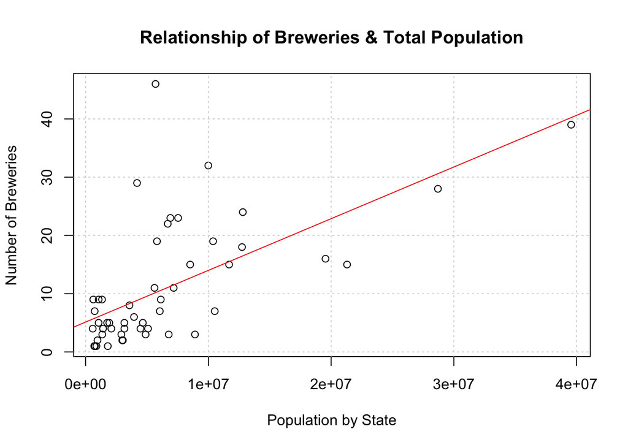

```r
grid(plot(combined_pop$Population, combined_pop$numBreweries,main="Relationship of Breweries & Total Population", xlab = "Population by State", ylab = "Number of Breweries"))
abline(brew_pop.lm, col = "red")
```

```r
numBreweries<-as.data.frame(numBreweries)
plot1<-as.data.frame(plot1)
albrew<- merge(plot1,numBreweries, by= "State")
head(albrew)
```

```
##   State Alcohol_content Bitterness numBreweries
## 1    AK          0.0560       46.0            7
## 2    AL          0.0600       43.0            3
## 3    AR          0.0520       39.0            2
## 4    AZ          0.0550       20.5           11
## 5    CA          0.0580       42.0           39
## 6    CO          0.0605       40.0           46
```

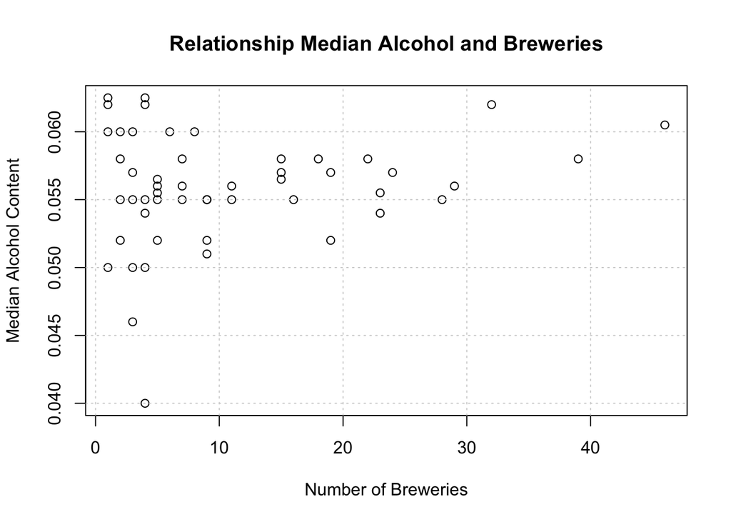

```r
grid(plot(albrew$numBreweries, albrew$Alcohol_content, main="Relationship Median Alcohol and Breweries", xlab = "Number of Breweries", ylab = "Median Alcohol Content"))
abline(brew_pop.lm, col = "red")
```

### Examining correlation between population and median alcohol content.The dataset albrew have the variable number of breweries from the dataset numBreweries created previously and the mediam alcohol content per bear from the dataset plot1 created before. So we combined the albrew with the state_population datatset from the census bureau in order to have the population variable added to the albrew dataset. The combined dataset of the albrew and satate_population is the alpop dataset. Furthermore, we proceeded to plot the relationship between the population per state and the median alcohol content. There is a poor correlation between median alcohol content and the population.

```r
merge(albrew, state_population, by = "State") ->alpop
head(alpop)
```

```
##   State Alcohol_content Bitterness numBreweries  StateFull Population
## 1    AK          0.0560       46.0            7     Alaska     737438
## 2    AL          0.0600       43.0            3    Alabama    4887871
## 3    AR          0.0520       39.0            2   Arkansas    3013825
## 4    AZ          0.0550       20.5           11    Arizona    7171646
## 5    CA          0.0580       42.0           39 California   39557045
## 6    CO          0.0605       40.0           46   Colorado    5695564
```

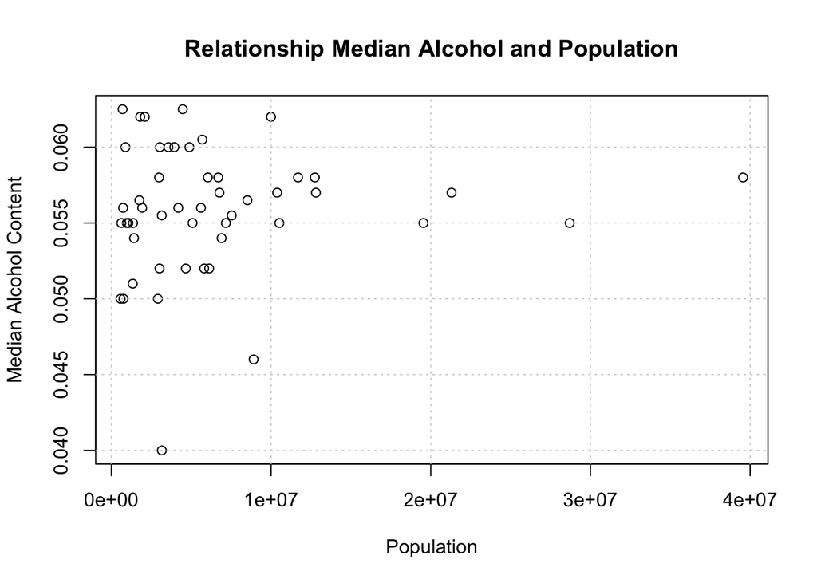

```r
grid(plot(alpop$Population, alpop$Alcohol_content, main="Relationship Median Alcohol and Population", xlab = "Population", ylab = "Median Alcohol Content"))
abline(brew_pop.lm, col = "red")
```